# **1. Introduction**

#### **Dimensionality Reduction**

```python
from sklearn.decomposition import PCA
from sklearn.preprocessing import StandardScaler
```

```python
numeric_features = df.select_dtypes(include=np.number).columns
X = df[numeric_features].fillna(df[numeric_features].median())
```

```python
scaler = StandardScaler()
X_scaled = scaler.fit_transform(X)
```

```python
pca = PCA()
pca_result = pca.fit_transform(X_scaled)
```

```python
explained_variance = pca.explained_variance_ratio_
cumulative_variance = explained_variance.cumsum()
```

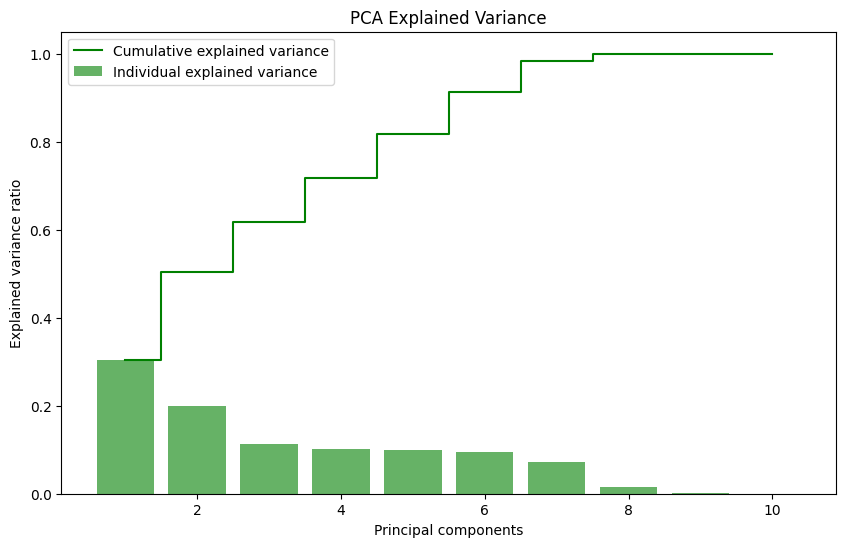

```python
plt.figure(figsize=(10, 6))
plt.bar(range(1, len(explained_variance) + 1), explained_variance, alpha=0.6,
        color='Green', label='Individual explained variance')
plt.step(range(1, len(cumulative_variance) + 1), cumulative_variance,
         where='mid', color='Green', label='Cumulative explained variance')
plt.ylabel('Explained variance ratio')
plt.xlabel('Principal components')
plt.legend()
plt.title('PCA Explained Variance')
plt.show()
```

```python
print("Explained variance by each component:")
for i, (exp_var, cum_var) in enumerate(zip(explained_variance, cumulative_variance)):
    print(f"PC{i+1}: {exp_var:.3f} (Cumulative: {cum_var:.3f})")

n_components_95 = np.argmax(cumulative_variance >= 0.95) + 1
print(f"\nComponents needed for 95% variance: {n_components_95}")
```

```
Explained variance by each component:
PC1: 0.304 (Cumulative: 0.304)
PC2: 0.200 (Cumulative: 0.504)
PC3: 0.112 (Cumulative: 0.617)
PC4: 0.101 (Cumulative: 0.717)
PC5: 0.099 (Cumulative: 0.817)
PC6: 0.096 (Cumulative: 0.912)
PC7: 0.071 (Cumulative: 0.984)
PC8: 0.015 (Cumulative: 0.998)
PC9: 0.001 (Cumulative: 1.000)
PC10: 0.000 (Cumulative: 1.000)

Components needed for 95% variance: 7
```

```python
feature_importance = pd.DataFrame(
    pca.components_.T,
    columns=[f'PC{i+1}' for i in range(pca.n_components_)],
    index=numeric_features
)

print("\nTop features in first 3 principal components:")
for i in range(3):
    print(f"\nPC{i+1} top features:")
    pc_features = feature_importance[f'PC{i+1}'].abs().sort_values(ascending=False).head(5)
    print(pc_features)
```

```
Top features in first 3 principal components:

PC1 top features:
reviews_total           0.553432
review_ratio            0.552291
reviews_total_log       0.535912
release_year            0.290503
review_score_percent    0.093736
Name: PC1, dtype: float64

PC2 top features:
discounted_price    0.706457
price               0.696490
discount_percent    0.122291
reviews_total       0.017980
review_ratio        0.017964
Name: PC2, dtype: float64

PC3 top features:
platform_count          0.751218
review_score_percent    0.467231
release_year            0.331627
engagement_rate         0.258146
review_ratio            0.143622
Name: PC3, dtype: float64
```

**Observations**

The PCA reveals that we need 7 components to capture 95% of the data's information, which is quite a lot. This tells us the dataset is complex, with multiple independent factors (like popularity, price, and platform support) driving the patterns.

#### **Central Tendency Measures**

```python
key_variables = ['price', 'discount_percent', 'review_score_percent',
                 'reviews_total', 'engagement_rate', 'discounted_price', 'review_ratio']
for var in key_variables:
    if var in df.columns:
        mean_val = df[var].mean()
        median_val = df[var].median()

        mode_result = df[var].mode()
        if len(mode_result) > 0:
            mode_val = mode_result.iloc[0]
        else:
            mode_val = np.nan

        std_val = df[var].std()
        skew_val = df[var].skew()

        print(f"\n{var.upper()}:")
        print(f"  Mean: {mean_val:.2f}")
        print(f"  Median: {median_val:.2f}")
        print(f"  Mode: {mode_val:.2f}")
        print(f"  Std Dev: {std_val:.2f}")
        print(f"  Skewness: {skew_val:.2f}")

        if abs(mean_val - median_val) / mean_val > 0.1:
            print(f"  → Distribution is skewed (mean ≠ median)")
        else:
            print(f"  → Distribution is relatively symmetric")

        if abs(skew_val) > 1:
            print(f"  → Highly skewed distribution")
        elif abs(skew_val) > 0.5:
            print(f"  → Moderately skewed distribution")
        else:
            print(f"  → Approximately symmetric distribution")

print("COMPARISON: ORIGINAL vs TRANSFORMED VARIABLES")

if 'reviews_total_log' in df.columns:
    print(f"\nReviews Total (Original):")
    print(f"  Skewness: {df['reviews_total'].skew():.2f}")
    print(f"  Mean: {df['reviews_total'].mean():.2f}, Median: {df['reviews_total'].median():.2f}")

    print(f"\nReviews Total (Log Transformed):")
    print(f"  Skewness: {df['reviews_total_log'].skew():.2f}")
    print(f"  Mean: {df['reviews_total_log'].mean():.2f}, Median: {df['reviews_total_log'].median():.2f}")
    print(f"  → Skewness reduced by: {df['reviews_total'].skew() - df['reviews_total_log'].skew():.2f}")

summary_stats = pd.DataFrame({
    'Mean': df[key_variables].mean(),
    'Median': df[key_variables].median(),
    'Std_Dev': df[key_variables].std(),
    'Skewness': df[key_variables].skew()
})

modes = []
for var in key_variables:
    mode_vals = df[var].mode()
    modes.append(mode_vals.iloc[0] if len(mode_vals) > 0 else np.nan)

summary_stats['Mode'] = modes
summary_stats['Mean_Median_Diff'] = abs(summary_stats['Mean'] - summary_stats['Median'])
```

```
PRICE:
  Mean: 81.97
  Median: 81.68
  Mode: 19.51
  Std Dev: 38.92
  Skewness: 0.02
  → Distribution is relatively symmetric
  → Approximately symmetric distribution

DISCOUNT_PERCENT:
  Mean: 10.81
  Median: 10.00
  Mode: 15.00
  Std Dev: 6.98
  Skewness: 0.30
  → Distribution is relatively symmetric
  → Approximately symmetric distribution

REVIEW_SCORE_PERCENT:
  Mean: 83.75
  Median: 86.00
  Mode: 94.00
  Std Dev: 11.51
  Skewness: -0.92
  → Distribution is relatively symmetric
  → Moderately skewed distribution

REVIEWS_TOTAL:
  Mean: 1295.89
  Median: 637.00
  Mode: 4361.75
  Std Dev: 1485.80
  Skewness: 1.16
  → Distribution is skewed (mean ≠ median)
  → Highly skewed distribution

ENGAGEMENT_RATE:
  Mean: 64.91
  Median: 65.15
  Mode: 55.60
```

[output cut: 17 more lines]

```
  Mode: 69.83
  Std Dev: 23.92
  Skewness: 1.16
  → Distribution is skewed (mean ≠ median)
  → Highly skewed distribution
COMPARISON: ORIGINAL vs TRANSFORMED VARIABLES

Reviews Total (Original):
  Skewness: 1.16
  Mean: 1295.89, Median: 637.00

Reviews Total (Log Transformed):
  Skewness: 0.17
  Mean: 6.38, Median: 6.46
  → Skewness reduced by: 0.99
```

**Observations**

This confirms our earlier findings: review counts are highly skewed, while prices and engagement rates are more balanced. The log transformation successfully made the review counts much more symmetrical.